# Midterm Exam - CHICAGO CRIMES DATA ANALYTICS PROJECT

### Analyst : John Paul U. Naynes

### Section : BSIT - 3B

```python
import pandas as pd
import warnings
import seaborn as sns
import matplotlib.pyplot as plt
warnings.filterwarnings('ignore')
```

```python
df = pd.read_csv('datasets\\Chicago_Crimes.csv')
df
```

|  | ID | Case Number | Date | Block | IUCR | Primary Type | Description | Location Description | Arrest | Domestic | ... | Ward | Community Area | FBI Code | X Coordinate | Y Coordinate | Year | Updated On | Latitude | Longitude | Location |
| --- | --- | --- | --- | --- | --- | --- | --- | --- | --- | --- | --- | --- | --- | --- | --- | --- | --- | --- | --- | --- | --- |
| 0 | 13439321 | JH237424 | 04/14/2024 12:00:00 AM | 040XX S PRAIRIE AVE | 0890 | THEFT | FROM BUILDING | APARTMENT | False | False | ... | 3 | 38.0 | 06 | 1178707.0 | 1878256.0 | 2024 | 12/21/2024 03:40:46 PM | 41.821236 | -87.619921 | (41.821236024, -87.619920712) |
| 1 | 13437420 | JH234779 | 04/14/2024 12:00:00 AM | 023XX W CERMAK RD | 2825 | OTHER OFFENSE | HARASSMENT BY TELEPHONE | COMMERCIAL / BUSINESS OFFICE | False | False | ... | 25 | 31.0 | 26 | 1161210.0 | 1889347.0 | 2024 | 12/21/2024 03:40:46 PM | 41.852052 | -87.683801 | (41.852051675, -87.683800849) |
| 2 | 13428676 | JH224478 | 04/14/2024 12:00:00 AM | 043XX W LE MOYNE ST | 0917 | MOTOR VEHICLE THEFT | CYCLE, SCOOTER, BIKE WITH VIN | STREET | False | False | ... | 36 | 23.0 | 07 | 1146960.0 | 1909501.0 | 2024 | 12/21/2024 03:40:46 PM | 41.907640 | -87.735587 | (41.907640473, -87.735587478) |
| 3 | 13429357 | JH225293 | 04/14/2024 12:00:00 AM | 039XX W ADAMS ST | 143A | WEAPONS VIOLATION | UNLAWFUL POSSESSION - HANDGUN | STREET | True | False | ... | 28 | 26.0 | 15 | 1150158.0 | 1898721.0 | 2024 | 12/21/2024 03:40:46 PM | 41.877997 | -87.724121 | (41.877997275, -87.724120826) |
| 4 | 13430098 | JH226395 | 04/14/2024 12:00:00 AM | 011XX W 112TH PL | 0890 | THEFT | FROM BUILDING | RESIDENCE | False | False | ... | 21 | 75.0 | 06 | 1170856.0 | 1830157.0 | 2024 | 12/21/2024 03:40:46 PM | 41.689421 | -87.650123 | (41.6894214, -87.650123247) |
| ... | ... | ... | ... | ... | ... | ... | ... | ... | ... | ... | ... | ... | ... | ... | ... | ... | ... | ... | ... | ... | ... |
| 249118 | 13805239 | JJ217509 | 04/12/2025 12:00:00 AM | 029XX W LOGAN BLVD | 2826 | OTHER OFFENSE | HARASSMENT BY ELECTRONIC MEANS | APARTMENT | False | False | ... | 1 | 22.0 | 26 | 1156478.0 | 1917149.0 | 2025 | 04/19/2025 03:41:24 PM | 41.928440 | -87.700416 | (41.928439867, -87.700415972) |
| 249119 | 13804023 | JJ215813 | 04/12/2025 12:00:00 AM | 094XX S HARVARD AVE | 0430 | BATTERY | AGGRAVATED - OTHER DANGEROUS WEAPON | STREET | False | False | ... | 9 | 49.0 | 04B | 1175694.0 | 1842631.0 | 2025 | 04/19/2025 03:41:24 PM | 41.723545 | -87.632040 | (41.723545182, -87.632039508) |
| 249120 | 13803926 | JJ215943 | 04/12/2025 12:00:00 AM | 084XX S VINCENNES AVE | 0486 | BATTERY | DOMESTIC BATTERY SIMPLE | APARTMENT | False | True | ... | 21 | 71.0 | 08B | 1173850.0 | 1848976.0 | 2025 | 04/19/2025 03:41:24 PM | 41.740998 | -87.638606 | (41.74099774, -87.638606337) |
| 249121 | 13803475 | JJ215338 | 04/12/2025 12:00:00 AM | 050XX S ABERDEEN ST | 0530 | ASSAULT | AGGRAVATED - OTHER DANGEROUS WEAPON | STREET | True | False | ... | 20 | 61.0 | 04A | 1169838.0 | 1871348.0 | 2025 | 04/19/2025 03:41:24 PM | 41.802477 | -87.652657 | (41.802477219, -87.652657244) |
| 249122 | 13804512 | JJ216668 | 04/12/2025 12:00:00 AM | 012XX W CARROLL AVE | 0710 | THEFT | THEFT FROM MOTOR VEHICLE | STREET | False | False | ... | 27 | 28.0 | 06 | 1168216.0 | 1902390.0 | 2025 | 04/19/2025 03:41:24 PM | 41.887694 | -87.657710 | (41.887694407, -87.657710204) |

249123 rows × 22 columns

```python
df['Date'] = df['Date'].astype(str)
df['Date'] = df['Date'].apply(lambda x: x.replace('/', '-') if pd.notnull(x) else x)
df['Date'] = df['Date'].apply(lambda x: x.strip() if pd.notnull(x) else x)
df['Date'] = pd.to_datetime(df['Date'], dayfirst=True, errors='coerce')
```

```python
df['Location Description'] = df['Location Description'].fillna('unknown_area')
df['Community Area'] = df['Community Area'].fillna('unknown_area')
df['X Coordinate'] = df['X Coordinate'].fillna(df['X Coordinate'].mean())
df['Y Coordinate'] = df['Y Coordinate'].fillna(df['Y Coordinate'].mean())
df['Latitude'] = df['Latitude'].fillna(df['Latitude'].mode()[0])
df['Longitude'] = df['Longitude'].fillna(df['Longitude'].mode()[0])
df['Location'] = df['Location'].fillna(df['Location'].mode()[0])
df.dtypes
df.isnull().sum()
```

[output not shown]

```python
df['Case Number'] = df['Case Number'].fillna('UNKNOWN_CASE')
df['Primary Type'] = df['Primary Type'].fillna('UNKNOWN_CRIME')
df['Description'] = df['Description'].fillna('NO_DESCRIPTION')
df['Arrest'] = df['Arrest'].fillna(False)
df['Domestic'] = df['Domestic'].fillna(False)
df['FBI Code'] = df['FBI Code'].fillna('UNKNOWN')
df['Year'] = df['Year'].fillna(df['Year'].mode()[0])
df['Date'] = df['Date'].fillna(df['Date'].mode()[0])

df.isnull().sum()
```

[output not shown]

```python
df['Year'] = df['Date'].dt.year
df['Month'] = df['Date'].dt.month
df['DayOfWeek'] = df['Date'].dt.dayofweek
df['Hour'] = df['Date'].dt.hour

crimes_per_year = df['Year'].value_counts().sort_index()
crimes_per_month = df['Month'].value_counts().sort_index()
crimes_per_day = df['DayOfWeek'].value_counts().sort_index()
```

# Chicago Crimes Analysis

## Chicago crimes showed clear monthly changes, with some months having the highest peaks, others staying consistently low, summer months recording more crimes than winter, a few months showing sudden increases, other months showing sharp drops, some months staying almost stable, and overall the pattern repeated in a seasonal cycle.

## Insight 1: overall monthly crime trend

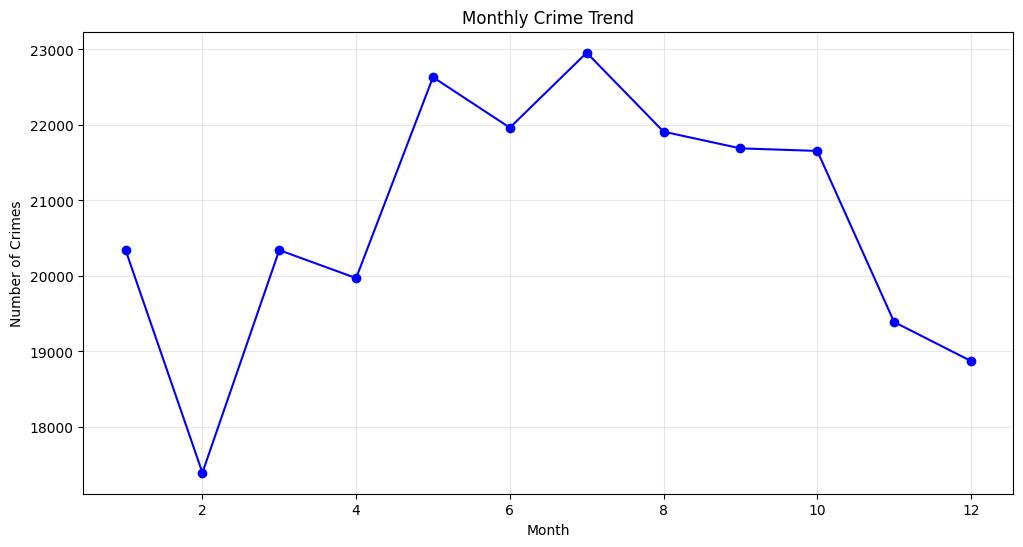

```python
monthly_trends = df.groupby('Month').size().reset_index(name='Total_Crimes')

plt.figure(figsize=(12,6))
plt.plot(monthly_trends['Month'], monthly_trends['Total_Crimes'], marker='o', color='blue')
plt.title("Monthly Crime Trend")
plt.xlabel("Month")
plt.ylabel("Number of Crimes")
plt.grid(True, alpha=0.3)
plt.show()
```

## This highlights the monthly crime trend of Chicago,which shows that july has the highest monthly crime rate

## Insight 2: Shows when the peak crime month is

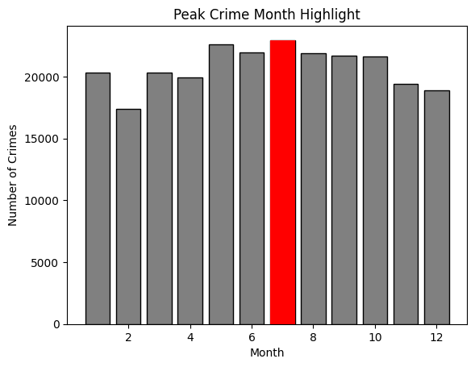

```python
peak_month = monthly_trends.loc[monthly_trends['Total_Crimes'].idxmax()]

plt.bar(monthly_trends['Month'], monthly_trends['Total_Crimes'], color='gray', edgecolor='black')
plt.bar(peak_month['Month'], peak_month['Total_Crimes'], color='red')
plt.title("Peak Crime Month Highlight")
plt.xlabel("Month")
plt.ylabel("Number of Crimes")
plt.show()
```

## This chart highlights July as the month with the most reported crimes.

## Insight 3: Shows when the month with the lowest crime is

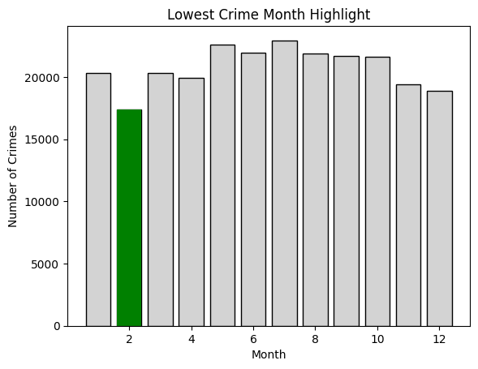

```python
low_month = monthly_trends.loc[monthly_trends['Total_Crimes'].idxmin()]

plt.bar(monthly_trends['Month'], monthly_trends['Total_Crimes'], color='lightgray', edgecolor='black')
plt.bar(low_month['Month'], low_month['Total_Crimes'], color='green')
plt.title("Lowest Crime Month Highlight")
plt.xlabel("Month")
plt.ylabel("Number of Crimes")
plt.show()
```

## February stands out as the month with the fewest crimes recorded.

## Insight 4: comparison betweeen the first half and the second half of the year

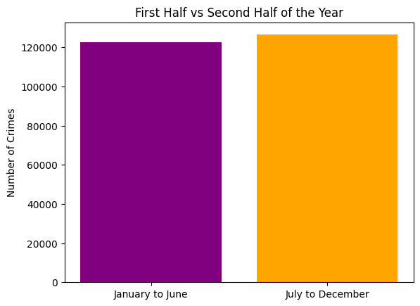

```python
first_half = monthly_trends.query("Month <= 6")['Total_Crimes'].sum()
second_half = monthly_trends.query("Month > 6")['Total_Crimes'].sum()

plt.bar(['January to June','July to December'], [first_half, second_half], color=['purple','orange'])
plt.title("First Half vs Second Half of the Year")
plt.ylabel("Number of Crimes")
plt.show()
```

## Insight 5: Identify which months have above/below average crime

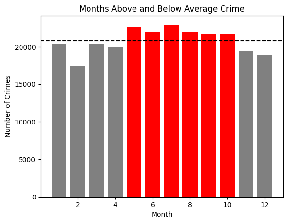

```python
avg_crime = monthly_trends['Total_Crimes'].mean()
above_avg = monthly_trends.loc[monthly_trends['Total_Crimes'] > avg_crime]
below_avg = monthly_trends.loc[monthly_trends['Total_Crimes'] <= avg_crime]

plt.bar(above_avg['Month'], above_avg['Total_Crimes'], color='red')
plt.bar(below_avg['Month'], below_avg['Total_Crimes'], color='gray')
plt.axhline(avg_crime, color='black', linestyle='--')
plt.title("Months Above and Below Average Crime")
plt.xlabel("Month")
plt.ylabel("Number of Crimes")
plt.show()
```

## Insight 6: Show month-to-month percentage changes

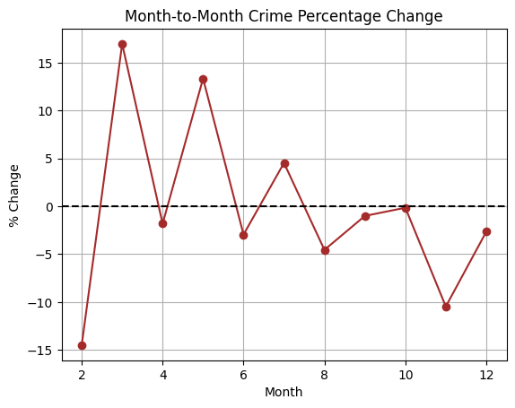

```python
monthly_trends['Pct_Change'] = monthly_trends['Total_Crimes'].pct_change() * 100

plt.plot(monthly_trends['Month'], monthly_trends['Pct_Change'], marker='o', color='brown')
plt.axhline(0, color='black', linestyle='--')
plt.title("Month-to-Month Crime Percentage Change")
plt.xlabel("Month")
plt.ylabel("% Change")
plt.grid()
plt.show()
```

## November clearly marks a sudden drop compared to the months before it.

## Insight 7: Heatmap of crimes by month and year

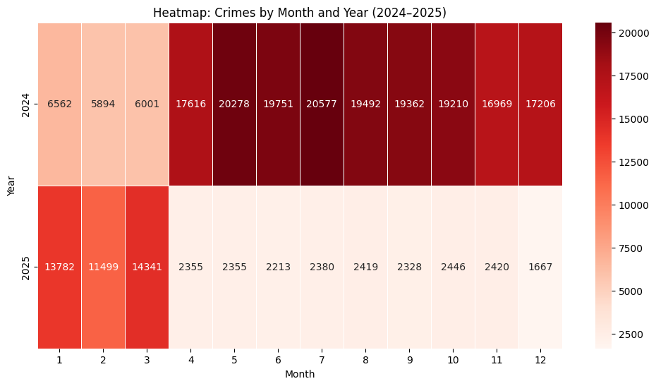

```python
monthly_heat = df.groupby(['Year','Month']).size().unstack(fill_value=0)

plt.figure(figsize=(12,6))
sns.heatmap(monthly_heat, cmap="Reds", annot=True, fmt="d", linewidths=0.5)
plt.title("Heatmap: Crimes by Month and Year (2024–2025)")
plt.xlabel("Month")
plt.ylabel("Year")
plt.show()
```

# Day of Week patterns for crimes in Chicago

```python
day_map = {0:'Monday', 1:'Tuesday', 2:'Wednesday', 3:'Thursday',
           4:'Friday', 5:'Saturday', 6:'Sunday'}
df['DayOfWeek'] = df['DayOfWeek'].map(day_map)

day_trends = df.groupby('DayOfWeek').size().reset_index(name='Counts')
day_order = ['Monday','Tuesday','Wednesday','Thursday','Friday','Saturday','Sunday']
day_trends['DayOfWeek'] = pd.Categorical(day_trends['DayOfWeek'], categories=day_order, ordered=True)
day_trends = day_trends.sort_values('DayOfWeek')
```

## Insight 8: Friday records the most crimes

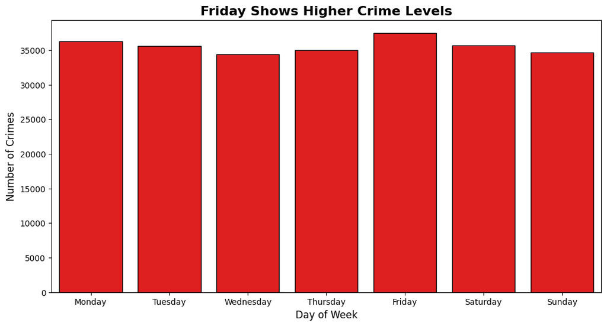

```python
plt.figure(figsize=(12,6))
sns.barplot(data=day_trends, x='DayOfWeek', y='Counts', color="red", edgecolor="black")
plt.title("Friday Shows Higher Crime Levels", fontsize=16, fontweight='bold')
plt.xlabel("Day of Week", fontsize=12)
plt.ylabel("Number of Crimes", fontsize=12)
plt.show()
```

## This chart highlights Friday as the busiest day with the most crime reports.

## Insight 9: Wednesday records the least crimes

[figure not shown]

```python
plt.figure(figsize=(12,6))
sns.lineplot(data=day_trends, x='DayOfWeek', y='Counts', color="blue", marker="o", linewidth=2)
plt.title("Sunday Has the Lowest Crime Levels", fontsize=16, fontweight='bold')
plt.xlabel("Day of Week", fontsize=12)
plt.ylabel("Number of Crimes", fontsize=12)
plt.grid(True, alpha=0.3)
plt.show()
```

## Insight 10: Weekdays have higher averages than weekends

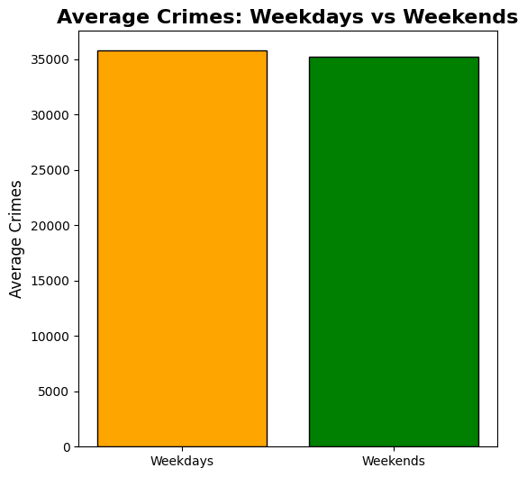

```python
weekday_avg = day_trends[day_trends['DayOfWeek'].isin(['Monday','Tuesday','Wednesday','Thursday','Friday'])]['Counts'].mean()
weekend_avg = day_trends[day_trends['DayOfWeek'].isin(['Saturday','Sunday'])]['Counts'].mean()

plt.figure(figsize=(6,6))
plt.bar(['Weekdays','Weekends'], [weekday_avg, weekend_avg], color=['orange','green'], edgecolor='black')
plt.title("Average Crimes: Weekdays vs Weekends", fontsize=16, fontweight='bold')
plt.ylabel("Average Crimes", fontsize=12)
plt.show()
```

## Weekdays show a higher average crime count compared to weekends.

## Insight 11: Crimes per Day across Years

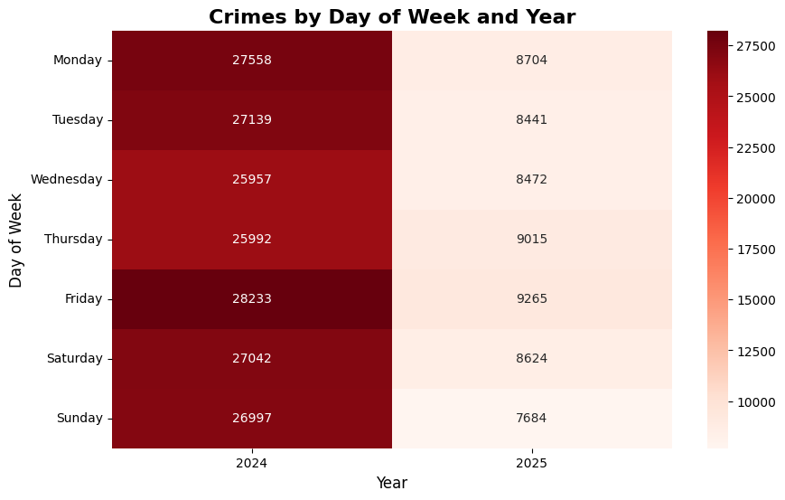

```python
heatmap_day_year = df.groupby(['DayOfWeek','Year']).size().unstack(fill_value=0)
heatmap_day_year = heatmap_day_year.reindex(day_order)

plt.figure(figsize=(10,6))
sns.heatmap(heatmap_day_year, cmap="Reds", annot=True, fmt="d", cbar=True)
plt.title("Crimes by Day of Week and Year", fontsize=16, fontweight='bold')
plt.xlabel("Year", fontsize=12)
plt.ylabel("Day of Week", fontsize=12)
plt.show()
```

## Insight 12: Saturday occasionally spikes

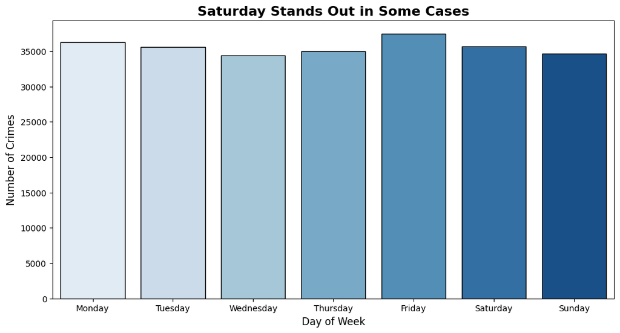

```python
plt.figure(figsize=(12,6))
sns.barplot(data=day_trends, x='DayOfWeek', y='Counts', palette="Blues", edgecolor="black")
plt.title("Saturday Stands Out in Some Cases", fontsize=16, fontweight='bold')
plt.xlabel("Day of Week", fontsize=12)
plt.ylabel("Number of Crimes", fontsize=12)
plt.show()
```

## This shows that Saturday has higher counts than Sunday(although they are both weekends),sometimes close to weekday levels.

## Insight 13: Midweek (Tue–Thu) stays stable

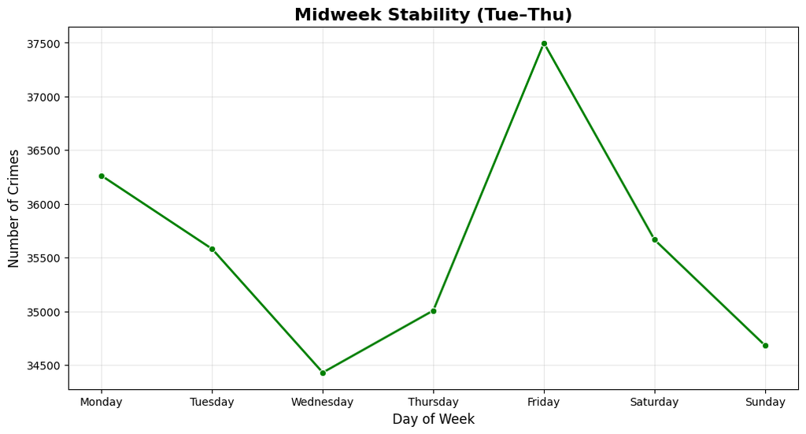

```python
plt.figure(figsize=(12,6))
sns.lineplot(data=day_trends[day_trends['DayOfWeek'].isin(['Monday','Tuesday','Wednesday','Thursday','Friday','Saturday','Sunday'])],
             x='DayOfWeek', y='Counts', marker="o", linewidth=2, color="green")
plt.title("Midweek Stability (Tue–Thu)", fontsize=16, fontweight='bold')
plt.xlabel("Day of Week", fontsize=12)
plt.ylabel("Number of Crimes", fontsize=12)
plt.grid(True, alpha=0.3)
plt.show()
```

## Tuesday to Thursday crimes stay steady without sharp increases or drops.

## Insight 14: Crimes by Day and Month

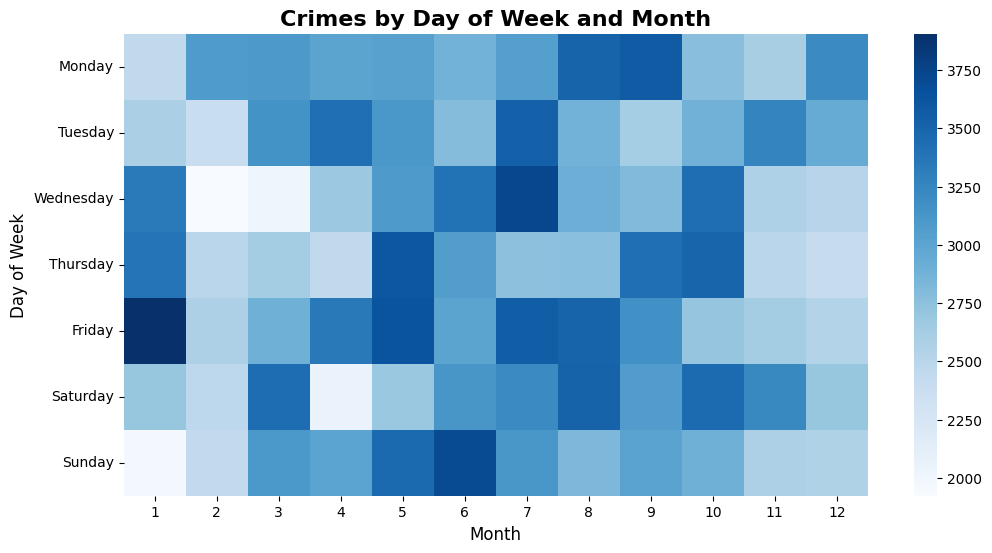

```python
heatmap_day_month = df.groupby(['DayOfWeek','Month']).size().unstack(fill_value=0)
heatmap_day_month = heatmap_day_month.reindex(day_order)

plt.figure(figsize=(12,6))
sns.heatmap(heatmap_day_month, cmap="Blues", annot=False, cbar=True)
plt.title("Crimes by Day of Week and Month", fontsize=16, fontweight='bold')
plt.xlabel("Month", fontsize=12)
plt.ylabel("Day of Week", fontsize=12)
plt.show()
```

## Crime locations in Chicago

## Crimes in Chicago often occurred in residential spaces, with streets and sidewalks also showing high cases, business areas recording frequent reports, public facilities like schools and parks seeing activity, transportation hubs experiencing occasional incidents, unknown areas filled in to ensure complete analysis, and overall patterns showing that crimes are spread across both public and private spaces.

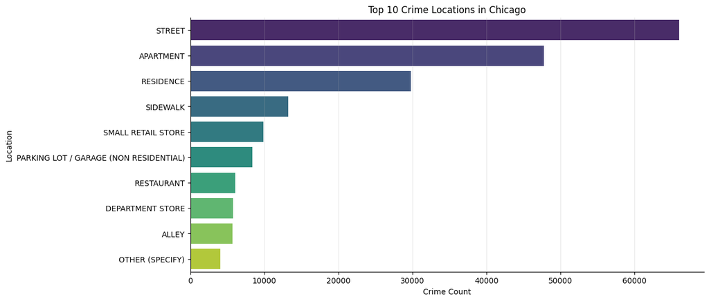

```python
location_counts = df['Location Description'].value_counts().reset_index()
location_counts.columns = ['Location Description', 'Counts']
top10_locations = location_counts.head(10)

plt.figure(figsize=(12,6))
sns.barplot(data=top10_locations,
            x='Counts',
            y='Location Description',
            palette='viridis')

sns.despine()
plt.title("Top 10 Crime Locations in Chicago")
plt.xlabel("Crime Count")
plt.ylabel("Location")
plt.grid(axis='x', alpha=0.3)
plt.show()
```

## Insight 16: Streets and sidewalks also record high crime counts

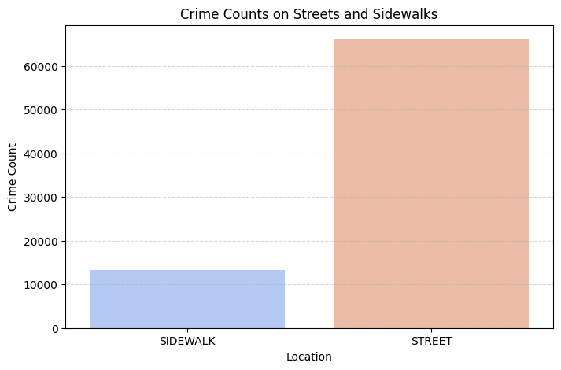

```python
street_sidewalk = df[df['Location Description'].isin(['STREET','SIDEWALK'])] \
                    .groupby('Location Description') \
                    .size().reset_index(name='Counts')

plt.figure(figsize=(8,5))
sns.barplot(data=street_sidewalk,
            x='Location Description',
            y='Counts',
            palette='coolwarm')

plt.title("Crime Counts on Streets and Sidewalks")
plt.xlabel("Location")
plt.ylabel("Crime Count")
plt.grid(axis='y', linestyle='--', alpha=0.5)
plt.show()
```

## Insight 17: Crimes in business areas

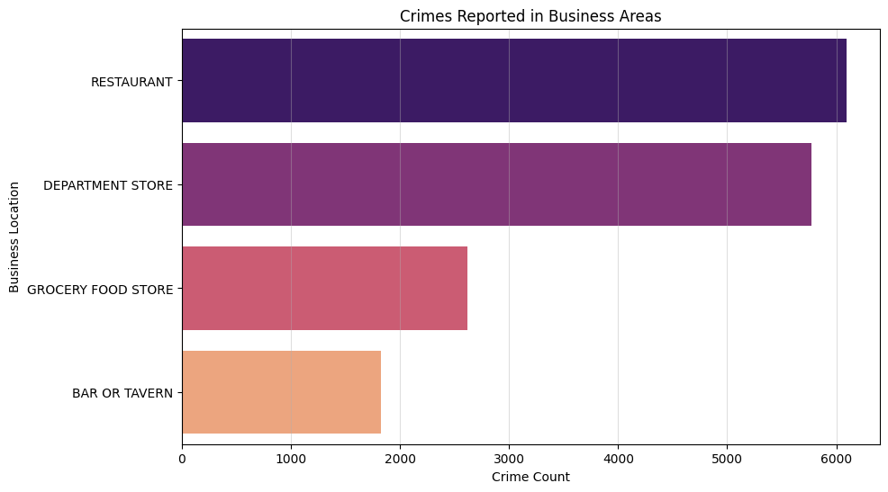

```python
business_places = df[df['Location Description'].isin(['GROCERY FOOD STORE','BAR OR TAVERN','DEPARTMENT STORE','RESTAURANT'])] \
                     .groupby('Location Description') \
                     .size().reset_index(name='Counts') \
                     .sort_values('Counts', ascending=False)

plt.figure(figsize=(10,6))
sns.barplot(data=business_places,
            x='Counts',
            y='Location Description',
            palette='magma')

plt.title("Crimes Reported in Business Areas")
plt.xlabel("Crime Count")
plt.ylabel("Business Location")
plt.grid(axis='x', alpha=0.4)
plt.show()
```

## Crimes in stores, bars, and restaurants highlight risks tied to commercial activity and nightlife.

## Insight 18: Crimes in public facilities like parks

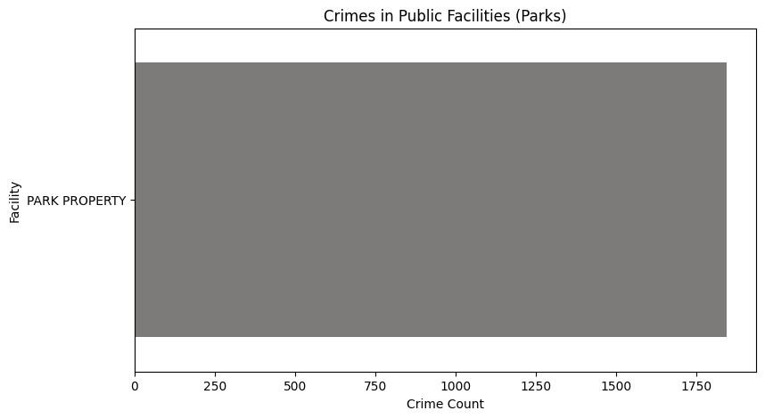

```python
public_facilities = df[df['Location Description'].isin(['PARK PROPERTY'])] \
                       .groupby('Location Description') \
                       .size().reset_index(name='Counts')

plt.figure(figsize=(9,5))
sns.barplot(data=public_facilities,
            x='Counts',
            y='Location Description',
            palette='cividis')

plt.title("Crimes in Public Facilities (Parks)")
plt.xlabel("Crime Count")
plt.ylabel("Facility")
plt.show()
```

## Public facilities like parks show lower but notable activity, often tied to community gatherings and open spaces.

## Insight 19: Crimes in transportation hubs

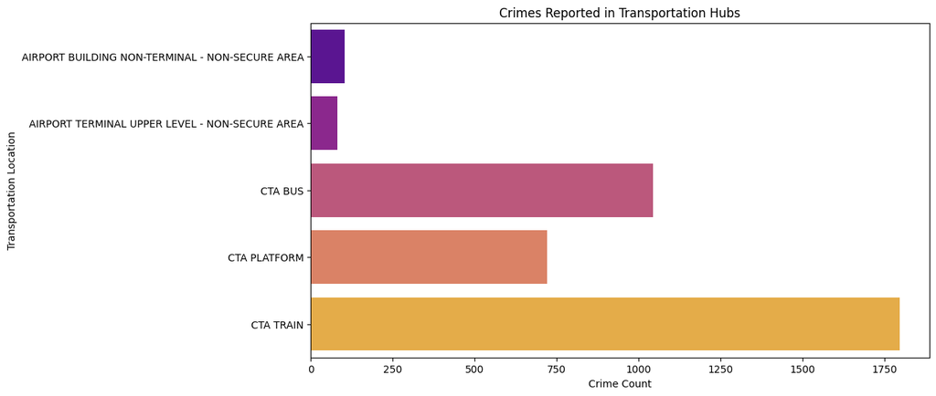

```python
transport_hubs = df[df['Location Description'].isin(['AIRPORT TERMINAL UPPER LEVEL - NON-SECURE AREA',
                                                     'CTA PLATFORM',
                                                     'CTA TRAIN',
                                                     'CTA BUS',
                                                     'AIRPORT BUILDING NON-TERMINAL - NON-SECURE AREA'])] \
                   .groupby('Location Description') \
                   .size().reset_index(name='Counts')

plt.figure(figsize=(11,6))
sns.barplot(data=transport_hubs,
            x='Counts',
            y='Location Description',
            palette='plasma')

plt.title("Crimes Reported in Transportation Hubs")
plt.xlabel("Crime Count")
plt.ylabel("Transportation Location")
plt.show()
```

## Transportation hubs like CTA buses and platforms still record incidents, reflecting urban mobility risks.

## Insight 20: Unknown areas recorded as 'unknown_area'

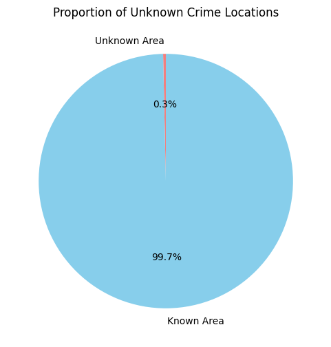

```python
unknowns = df[df['Location Description'] == 'unknown_area'].shape[0]

plt.figure(figsize=(6,6))
plt.pie([unknowns, len(df)-unknowns],
        labels=['Unknown Area','Known Area'],
        autopct='%1.1f%%',
        colors=['lightcoral','skyblue'],
        startangle=90)

plt.title("Proportion of Unknown Crime Locations")
plt.show()
```

## Unknown locations form a small but important part of the dataset, ensuring no missing values distort analysis.

## Insight 21: Crimes by location and month

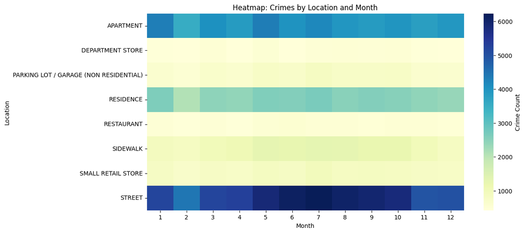

```python
top_locations = df['Location Description'].value_counts().head(8).index
heatmap_data = df[df['Location Description'].isin(top_locations)] \
                   .groupby(['Month','Location Description']) \
                   .size().reset_index(name='Counts')

heatmap_pivot = heatmap_data.pivot(index='Location Description', columns='Month', values='Counts').fillna(0)

plt.figure(figsize=(12,6))
sns.heatmap(heatmap_pivot, cmap='YlGnBu', annot=False, cbar_kws={'label':'Crime Count'})
plt.title("Heatmap: Crimes by Location and Month")
plt.xlabel("Month")
plt.ylabel("Location")
plt.show()
```

## The heatmap shows residential and street crimes peaking in summer, while business and public facilities show steadier patterns.

## Crimes in Chicago show varied patterns, with differences between arrests and non-arrests, domestic and non-domestic cases, crime types, and community distribution, where location and timing also reveal strong influences on crime activities.

## Insight 22: Arrests are less frequent than non-arrests

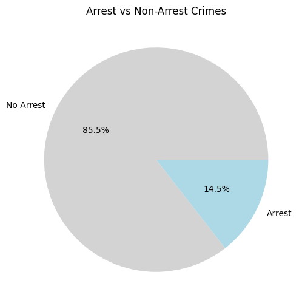

```python
arrest_counts = df['Arrest'].value_counts()

plt.figure(figsize=(6,6))
plt.pie(arrest_counts, labels=['No Arrest','Arrest'],
        autopct='%1.1f%%', colors=['lightgray','lightblue'])
plt.title("Arrest vs Non-Arrest Crimes")
plt.show()
```

## This pie chart shows that the majority of crimes did not result in arrests, suggesting that many incidents remain unresolved or that arrests happen later.

## Insight 23: Domestic vs Non-Domestic Crimes

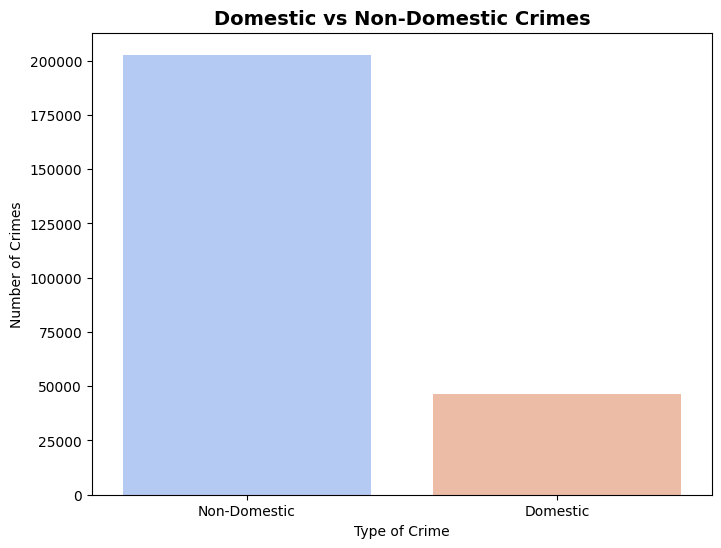

```python
df['Domestic Crime'] = df['Domestic'].map({True: 'Domestic', False: 'Non-Domestic'})

domestic_counts = df['Domestic Crime'].value_counts()

plt.figure(figsize=(8,6))
sns.barplot(
    x=domestic_counts.index,
    y=domestic_counts.values,
    palette="coolwarm"
)
plt.title("Domestic vs Non-Domestic Crimes", fontsize=14, fontweight="bold")
plt.xlabel("Type of Crime")
plt.ylabel("Number of Crimes")
plt.show()
```

## Non-domestic crimes has a higher count, but domestic cases remain significant, showing that household-related crimes are a consistent issue.

## Insight 24: Distribution of Crime Types

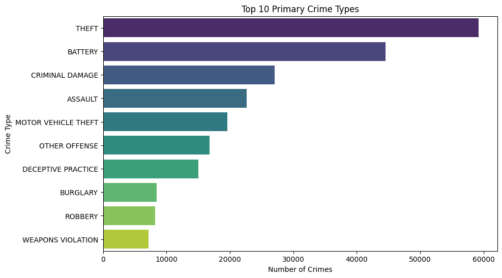

```python
crime_types = df['Primary Type'].value_counts().head(10)

plt.figure(figsize=(10,6))
sns.barplot(x=crime_types.values, y=crime_types.index, palette="viridis")
plt.title("Top 10 Primary Crime Types")
plt.xlabel("Number of Crimes")
plt.ylabel("Crime Type")
plt.show()
```

## The most common crimes are theft and battery, while serious offenses like homicide are fewer, highlighting everyday issues dominating crime reports.

## Insight 25: Crime Descriptions Provide Detail

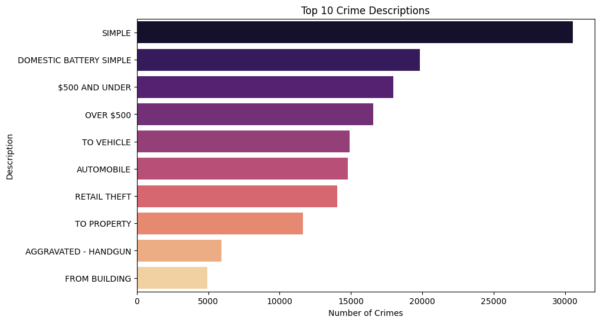

```python
descriptions = df['Description'].value_counts().head(10)

plt.figure(figsize=(10,6))
sns.barplot(x=descriptions.values, y=descriptions.index, palette="magma")
plt.title("Top 10 Crime Descriptions")
plt.xlabel("Number of Crimes")
plt.ylabel("Description")
plt.show()
```

## The descriptions shows the broader crime categories, showing that theft and assault appear under multiple variations, revealing nuanced crime behaviors.

## Insight 26: Crime Trends by Year

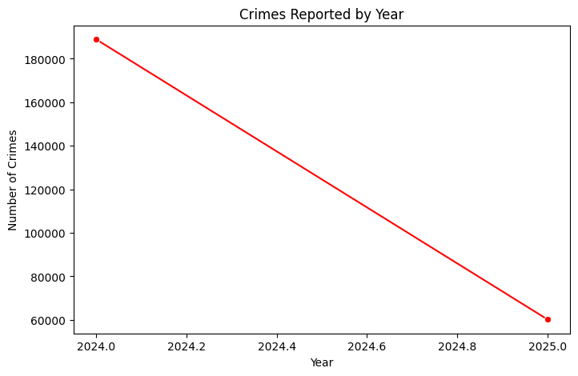

```python
yearly_trends = df['Year'].value_counts().sort_index()

plt.figure(figsize=(8,5))
sns.lineplot(x=yearly_trends.index, y=yearly_trends.values, marker='o', color="red")
plt.title("Crimes Reported by Year")
plt.xlabel("Year")
plt.ylabel("Number of Crimes")
plt.show()
```

## Crimes in 2024 appear higher than in 2025, though the dataset may still be incomplete for the current year.

## Insight 27: Crimes per Month

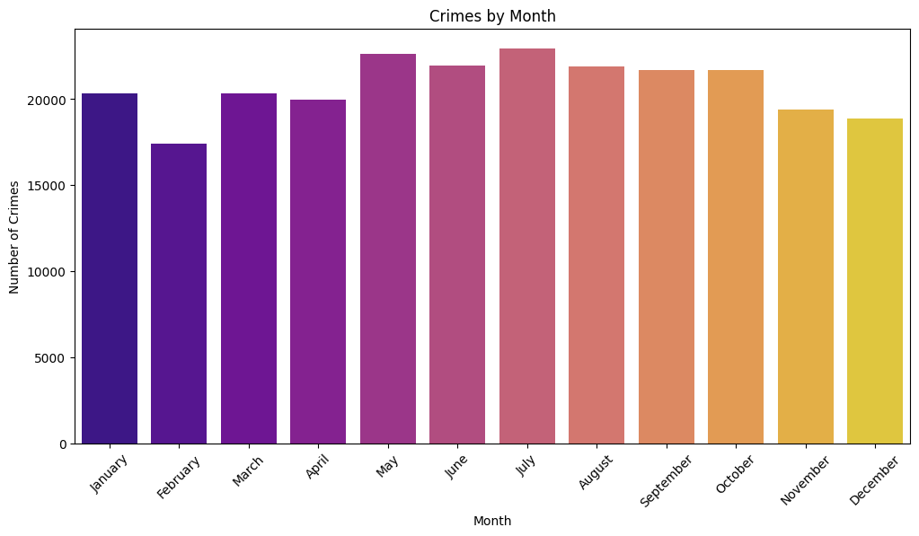

```python
month_map = {1:"January",2:"February",3:"March",4:"April",5:"May",6:"June",
             7:"July",8:"August",9:"September",10:"October",11:"November",12:"December"}
df['Month_Name'] = df['Month'].map(month_map)

monthly_trends = df['Month_Name'].value_counts().reindex(month_map.values())

plt.figure(figsize=(12,6))
sns.barplot(x=monthly_trends.index, y=monthly_trends.values, palette="plasma")
plt.title("Crimes by Month")
plt.xlabel("Month")
plt.ylabel("Number of Crimes")
plt.xticks(rotation=45)
plt.show()
```

## Some months, like July and August, show higher crime activity, which may link to seasonal trends or increased outdoor activity.

## Insight 28: Crimes by Hour of Day

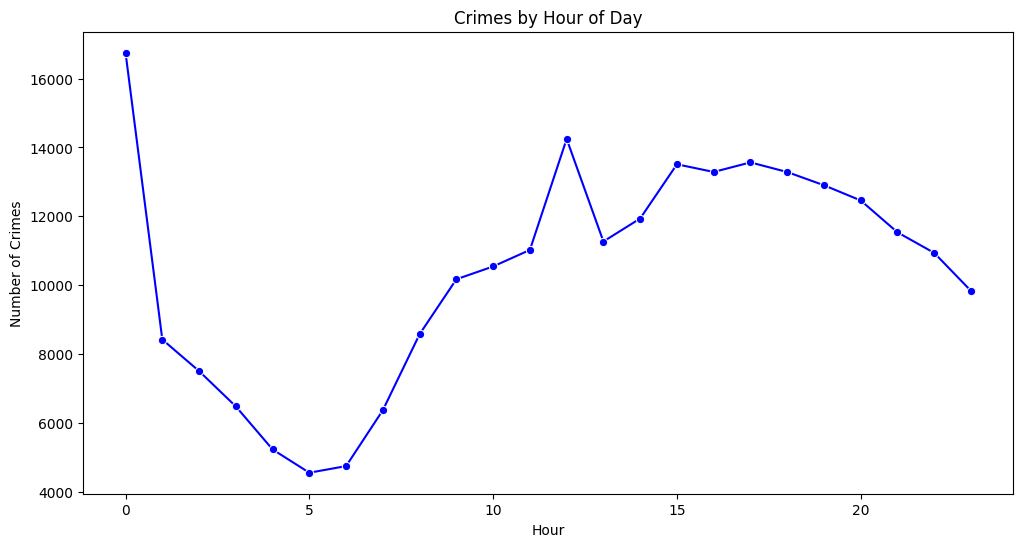

```python
hour_trends = df['Hour'].value_counts().sort_index()

plt.figure(figsize=(12,6))
sns.lineplot(x=hour_trends.index, y=hour_trends.values, marker='o', color="blue")
plt.title("Crimes by Hour of Day")
plt.xlabel("Hour")
plt.ylabel("Number of Crimes")
plt.show()
```

## Insight 29: Heatmap of Arrests by Day and Hour

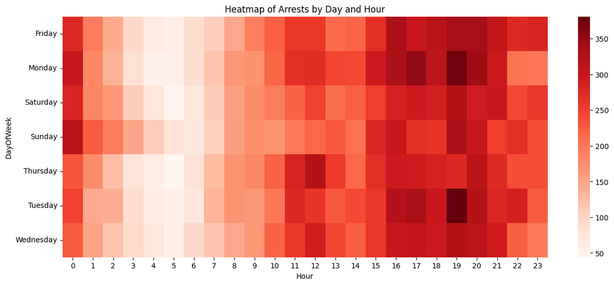

```python
arrest_heatmap = df.pivot_table(index='DayOfWeek', columns='Hour', values='Arrest', aggfunc='sum')

plt.figure(figsize=(15,6))
sns.heatmap(arrest_heatmap, cmap="Reds")
plt.title("Heatmap of Arrests by Day and Hour")
plt.show()
```

## Insight 30: Heatmap of Domestic Crimes by Day and Hour

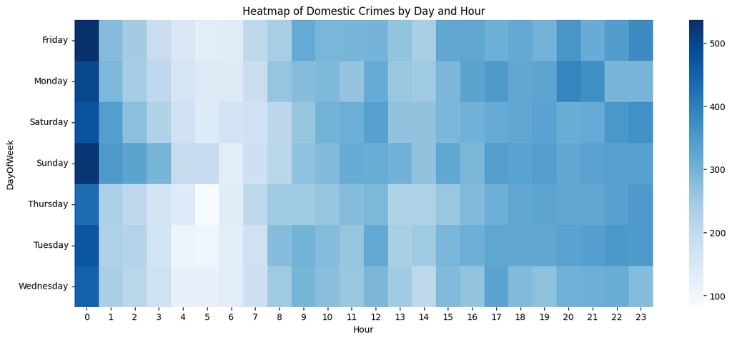

```python
domestic_heatmap = df.pivot_table(index='DayOfWeek', columns='Hour', values='Domestic', aggfunc='sum')

plt.figure(figsize=(15,6))
sns.heatmap(domestic_heatmap, cmap="Blues")
plt.title("Heatmap of Domestic Crimes by Day and Hour")
plt.show()
```

## Domestic crimes are more frequent at night, especially on weekends, indicating household disputes escalate during late hours.

## Insight 31: Heatmap of Arrests by Month and Day of Week

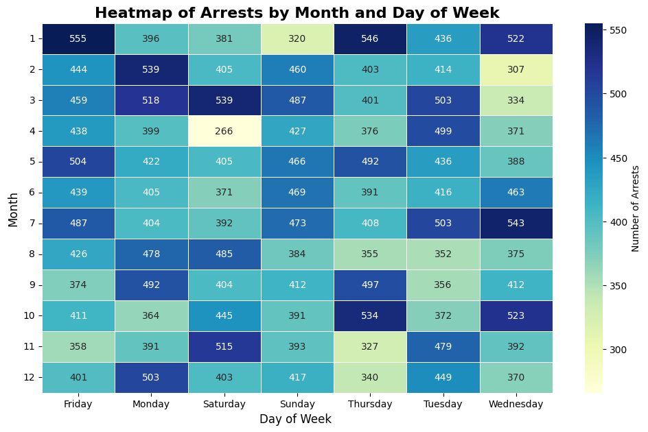

```python
arrest_heatmap = pd.crosstab(df['Month'], df['DayOfWeek'], values=df['Arrest'], aggfunc='sum').fillna(0)

plt.figure(figsize=(12,7))
sns.heatmap(
    arrest_heatmap,
    cmap="YlGnBu",
    annot=True,
    fmt=".0f",
    linewidths=0.5,
    cbar_kws={'label': 'Number of Arrests'}
)
plt.title('Heatmap of Arrests by Month and Day of Week', fontsize=16, fontweight='bold')
plt.xlabel('Day of Week ', fontsize=12)
plt.ylabel('Month', fontsize=12)
plt.xticks(rotation=0)
plt.yticks(rotation=0)
plt.show()
```